# Assignment_2_amahmoo6

assignment 2 asam mahmood

```python
from math import log2
```

### Question 3 [2 pts]: In database showing in Table 1, please calculate the Entropy of the whole dataset (0.5 pt). Use information gain to determine which attribute has the highest Information Gain (1.5 pts) (List major steps)

### Question 3a please calculate the Entropy of the whole dataset (0.5 pt)

$-\frac{9}{15} log_{2} \frac{9}{15}-\frac{6}{15} log_{2} \frac{6}{15} =.9709 $

Question 3b

Use information gain to determine which attribute has the highest Information Gain (1.5 pts)

Monday $-\frac{3}{3} log_{2} \frac{3}{3}$ = 0

Tuesday $ \frac{1}{2} log_{2} \frac{1}{2} + \frac{1}{2} log_{2} \frac{1}{2}$ = 1

Wednesday $\frac{2}{2} log_{2} \frac{2}{2}$ = 0

Thursday $ \frac{2}{2} log_{2} \frac{2}{2}$ = 0

Friday $ \frac{2}{2} log_{2} \frac{2}{2}$ = 0

Saturday $ -\frac{2}{2} log_{2} \frac{2}{2}$ = 0

Sunday $ -\frac{2}{2} log_{2} \frac{2}{2}$ = 0

$ Information Gain Days = .9709 - \frac{3}{15}(0) + \frac{2}{15}(1) + \frac{2}{15}(0)+ \frac{2}{15}(0)+ \frac{2}{15}(0) + \frac{2}{15}(0) + \frac{2}{15}(0) = .8376$

```python
.9709 - ((3/15)*(0) + (2/15)*(1) + (2/15)*(0)+ (2/15)*(0)+ (2/15)*(0)+ (2/15)*(0))
```

```
0.8375666666666667
```

.9709 - 2/15 = .8376

outlook OverCast $ -\frac{1}{4} log_{2} \frac{1}{4} - \frac{3}{4} log_{2} \frac{3}{4}$ = .8113

outlook rain $ -\frac{4}{6} log_{2} \frac{4}{6} - \frac{2}{6} log_{2} \frac{2}{6}$ = .9182

outlook sunny $ -\frac{3}{5} log_{2} \frac{3}{5} - \frac{2}{5} log_{2} \frac{2}{5}$ = .9709505944546686

```python
-(3/5)*log2(3/5) - (2/5)*log2(2/5)
```

```
0.9709505944546686
```

$ Information Gain outlook = .9709 - [\frac{4}{15}(.8112) + \frac{6}{15}(.9182) + \frac{5}{15}(.9709)] = 0.06366666666666654$

```python
.9709 - ((4/15)*(.8112) + (6/15)*(.9182) + (5/15)*(.9709))
```

```
0.06366666666666654
```

temperature cool $ -\frac{3}{4} log_{2} \frac{3}{4} - \frac{1}{4} log_{2} \frac{1}{4}$ = 0.8112781244591328

```python
-(3/4)*log2(3/4) - (1/4)*log2(1/4)
```

```
0.8112781244591328
```

temperature hot $ -\frac{2}{4} log_{2} \frac{2}{4} - \frac{2}{4} log_{2} \frac{2}{4}$ = 1

```python
-(2/4)*log2(2/4) - (2/4)*log2(2/4)
```

```
1.0
```

temperature mild $ -\frac{4}{7} log_{2} \frac{4}{7} - \frac{3}{7} log_{2} \frac{3}{7}$ = 0.9852281360342516

```python
-(4/7)*log2(4/7) - (3/7)*log2(3/7)
```

```
0.9852281360342516
```

$ Information Gain Temperature = .9709 - [\frac{4}{15}(.8112781244591328) + \frac{4}{15}(1) + \frac{7}{15}(.9852281360342516)] = 0.028119369994913823$

```python
.9709 - ((4/15)*(.8112781244591328) + (4/15)*(1) + (7/15)*(.9852281360342516))
```

```
0.028119369994913823
```

humidity high $ -\frac{4}{8} log_{2} \frac{4}{8} - \frac{4}{8} log_{2} \frac{4}{8}$ = 1

```python
-(4/8)*log2(4/8) - (4/8)*log2(4/8)
```

```
1.0
```

humidity normal $ -\frac{5}{7} log_{2} \frac{5}{7} - \frac{2}{7} log_{2} \frac{2}{7}$ = 0.863120568566631

```python
-(5/7)*log2(5/7) - (2/7)*log2(2/7)
```

```
0.863120568566631
```

$ Information Gain Humidity = .9709 - [\frac{8}{15}(1) + \frac{7}{15}(.863120568566631) ] = 0.0347770680022389$

```python
.9709 - ((8/15)*(1) + (7/15)*(.863120568566631))
```

```
0.0347770680022389
```

wind strong $ -\frac{4}{7} log_{2} \frac{4}{7} - \frac{3}{7} log_{2} \frac{3}{7}$ = 0.9852281360342516

```python
-(4/7)*log2(4/7) - (3/7)*log2(3/7)
```

```
0.9852281360342516
```

wind weak $ -\frac{5}{8} log_{2} \frac{5}{8} - \frac{3}{8} log_{2} \frac{3}{8}$ = 0.0.954434002924965

```python
-(5/8)*log2(5/8) - (3/8)*log2(3/8)
```

```
0.954434002924965
```

$Information Gain Wind = .9709 - [\frac{7}{15}(.9852281360342516) + \frac{8}{15}(.954434002924965) ] = 0.002095401624034543$

```python
.9709 - ((7/15)*(.9852281360342516) + (8/15)*(.954434002924965))
```

```
0.002095401624034543
```

$ Information Gain Days = .9709 - \frac{3}{15}(0) + \frac{2}{15}(1) + \frac{2}{15}(0)+ \frac{2}{15}(0)+ \frac{2}{15}(0) + \frac{2}{15}(0) + \frac{2}{15}(0) = .8376$ $ Information Gain outlook = .9709 - [\frac{4}{15}(.8112) + \frac{6}{15}(.9182) + \frac{5}{15}(.9709)] = 0.06366666666666654$ $ Information Gain Temperature = .9709 - [\frac{4}{15}(.8112781244591328) + \frac{4}{15}(1) + \frac{7}{15}(.9852281360342516)] = 0.028119369994913823$ $ Information Gain Humidity = .9709 - [\frac{8}{15}(1) + \frac{7}{15}(.863120568566631) ] = 0.0347770680022389$ $ Information Gain Wind = .9709 - [\frac{7}{15}(.9852281360342516) + \frac{8}{15}(.954434002924965) ] = 0.002095401624034543$

Question 4 [2.5 pts]: In the dataset showing in Table 1, please calculate Information Gain Ratio of each attributes, and report the Information Gain Ratio values of each attribute [2 pts], and determine which attribute should be selected as the root note of the decision tree [0.5 pt]

days $-\frac{3}{15}log{2} \frac{3}{15} - 6\frac{2}{15} log_{2} \frac{3}{15}$ = 0.3002260194957439

```python
.8376/ (-(3/15)*log2(3/15) - 6*((2/15)*log2(2/15)))
```

```
0.3002260194957439
```

outlook $-\frac{4}{15}log{2} \frac{4}{15} - \frac{6}{15} log_{2} \frac{6}{15} -\frac{5}{15} log_{2} \frac{5}{15} $ = 0.040666083267282944

```python
.06366666666666654/ (-(4/15)*log2(4/15) - (6/15)*log2(6/15)- (5/15)*log2(5/15))
```

```
0.040666083267282944
```

temperature $\frac{4}{15}log{2} \frac{4}{15} - \frac{4}{15} log_{2} \frac{4}{15} -\frac{7}{15} log_{2} \frac{7}{15} $ = 0.018377172212941162

```python
.028119369994913823/ (-(4/15)*log2(4/15) - (4/15)*log2(4/15)- (7/15)*log2(7/15))
```

```
0.018377172212941162
```

humidity $\frac{8}{15}log{2} \frac{8}{15} - \frac{7}{15} log_{2} \frac{7}{15} -\frac{7}{15} log_{2} \frac{7}{15} $ = 0.034889004769333355

```python
.0347770680022389/ (-(8/15)*log2(8/15) - (7/15)*log2(7/15))
```

```
0.034889004769333355
```

```python
0.002095401624034543/ (-(7/15)*log2(7/15) - (8/15)*log2(8/15))
```

```
0.002102146082294906
```

##### Question 5 [2 pts]: Using dataset in Table 1 and Information Gain Ratio to create a decision tree with maximum two layers (i.e., the maximum depth of the tree is 2. The root node has 0 depth). List major steps of the tree constructions and report the final decision tree [2 pts]

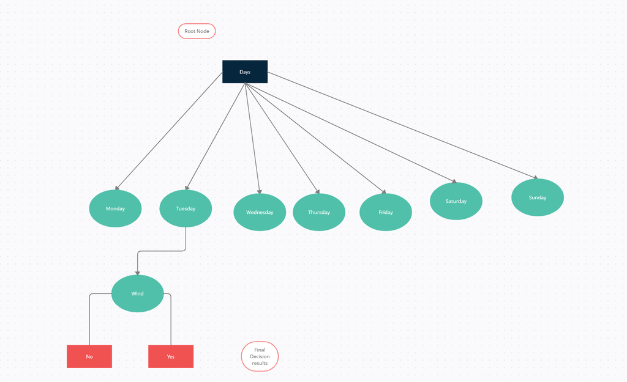

##### Above I used days as root node. The reason I used days was because the information gain above was the best resulting option. I broke days into each conditional leafs based on attributes of days. I selected wind because you on tuesday it was the only one with a result ##### of both classifications. Yopu can see its results in 2 layers based on requirements.

##### Question 6 [2.5 pts]: In the dataset showing in Table 1, please use Gini Index to calculate the correlation between each of the four attributes (outlook, temperature, humidity, wind) to the Class label, respectively [2 pts]. Please rank and select the most important attribute to build the root node of the decision tree [0.5 pt].

days $1- [\frac{1}{2}^2 +\frac{1}{2}^2] $ = 1/2

days $ 1- [\frac{3}{3}^2] $ = 0

$\frac{3}{15} * 0 + \frac{2}{15}* \frac{1}{2} + \frac{2}{15} * 0 + \frac{2}{15} * 0+ \frac{2}{15} * 0 + \frac{2}{15} * 0 $ = 0.06666666666666667

```python
1-(((3/4)**2) + ((1/4)**2))
```

```
0.375
```

```python
1-(((4/6)**2) + ((2/6)**2))
```

```
0.4444444444444444
```

```python
1-(((2/5)**2) + ((3/5)**2))
```

```
0.48
```

```python
(4/15 * .375) + ((6/15)* 0.4444444444444444) + (5/15 * .48)
```

```
0.43777777777777777
```

```python
1-(((1/4)**2) + ((3/4)**2))
```

```
0.375
```

```python
1-(((2/4)**2) + ((2/4)**2))
```

```
0.5
```

```python
1-(((4/7)**2) + ((3/7)**2))
```

```
0.48979591836734704
```

Gini Index temperature = $\frac{4}{15} * .375 + \frac{4}{15}* 0.5 + \frac{7}{15} * .48979591836734704 $ = 0.46190476190476193

```python
(4/15 * .375) + ((4/15)* 0.5) + (7/15 * 0.48979591836734704)
```

```
0.46190476190476193
```

```python
1-(((4/8)**2) + ((4/8)**2))
```

```
0.5
```

```python
1-(((5/7)**2) + ((2/7)**2))
```

```
0.40816326530612246
```

Gini Index humidty = $\frac{8}{15} * 0.5 + \frac{7}{15}* 0.40816326530612246 $ = 0.4571428571428572

```python
(8/15 * 0.5) + ((7/15)* .40816326530612246)
```

```
0.4571428571428572
```

```python
1-(((4/7)**2) + ((3/7)**2))
```

```
0.48979591836734704
```

```python
1-(((5/8)**2) + ((3/8)**2))
```

```
0.46875
```

Gini Index wind = $\frac{7}{15} * .48979591836734704 + \frac{8}{15}* .46875 $ = 0.47857142857142865

```python
(7/15 * 0.48979591836734704) + ((8/15)* 0.46875)
```

```
0.47857142857142865
```

#### rank and order:

#### Gini Index Days = 0 0.06666666666666667

#### Gini Index Outlook = 0.43777777777777777

#### Gini Index temperature = 0.46190476190476193

#### Gini Index humidty = 0.4571428571428572

#### Gini Index wind = 0.47857142857142865

##### Question 7 [1 pt]: Please download housing.header.binary.txt dataset from Canvas, and use Python (or R) to implement tasks below (This dataset is the same as housing.header.txt, except that the last feature Medv is discretized with Medv value of the house greater than 230k being 1, or 0 otherwise.)

```python
%matplotlib inline
import matplotlib.pyplot as plt
import pandas as pd
import numpy as np

df_housing_header_binary = pd.read_csv("housing.header.binary.txt")
df_housing_header_binary.head()
```

|  | Crim | Zn | Indus | Chas | Nox | Rm | Age | Dis | Rad | Tax | Ptratio | B | Lstat | Medv |
| --- | --- | --- | --- | --- | --- | --- | --- | --- | --- | --- | --- | --- | --- | --- |
| 0 | 0.00632 | 18.0 | 2.31 | 0 | 0.538 | 6.575 | 65.2 | 4.0900 | 1 | 296 | 15.3 | 396.90 | 4.98 | 1 |
| 1 | 0.02731 | 0.0 | 7.07 | 0 | 0.469 | 6.421 | 78.9 | 4.9671 | 2 | 242 | 17.8 | 396.90 | 9.14 | 0 |
| 2 | 0.02729 | 0.0 | 7.07 | 0 | 0.469 | 7.185 | 61.1 | 4.9671 | 2 | 242 | 17.8 | 392.83 | 4.03 | 1 |
| 3 | 0.03237 | 0.0 | 2.18 | 0 | 0.458 | 6.998 | 45.8 | 6.0622 | 3 | 222 | 18.7 | 394.63 | 2.94 | 1 |
| 4 | 0.06905 | 0.0 | 2.18 | 0 | 0.458 | 7.147 | 54.2 | 6.0622 | 3 | 222 | 18.7 | 396.90 | 5.33 | 1 |

#### • Use “Crim” and “Rm” as independent variables to train a decision tree (0.5 pt) to predict

#### whether a house value Medv is 1 or 0 (i.e., whether the house value is greater than 230k

#### or not).

```python
independent_variables = df_housing_header_binary[["Crim", "Rm"]]
print(independent_variables)
prediction_variable = df_housing_header_binary["Medv"]
print(prediction_variable)
```

```
        Crim     Rm
0    0.00632  6.575
1    0.02731  6.421
2    0.02729  7.185
3    0.03237  6.998
4    0.06905  7.147
..       ...    ...
501  0.06263  6.593
502  0.04527  6.120
503  0.06076  6.976
504  0.10959  6.794
505  0.04741  6.030

[506 rows x 2 columns]
0      1
1      0
2      1
3      1
4      1
      ..
501    0
502    0
503    1
504    0
505    0
Name: Medv, Length: 506, dtype: int64
```

#### • Visualize the tree (including nodes and lables), and explain the meaning of the values

#### showing in the root node (0.5 pt).

```python
from sklearn.tree import DecisionTreeClassifier
from sklearn import tree
import seaborn as sns

decision_tree_classifier = tree.DecisionTreeClassifier(max_depth=4)
decision_tree_classifier.fit(independent_variables,prediction_variable)
```

```
DecisionTreeClassifier(max_depth=4)
```

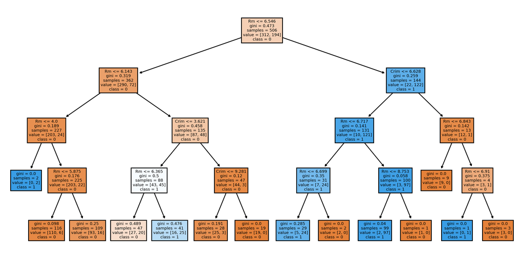

```python
fig, axes = plt.subplots(nrows = 1,ncols = 1,figsize = (12,6), dpi=400)
tree.plot_tree(decision_tree_classifier,feature_names = independent_variables.columns, class_names=['0','1'],filled = True)
plt.show()
```

```python
decision_tree_classifier_with_depth = tree.DecisionTreeClassifier(max_depth=2)
decision_tree_classifier_with_depth.fit(independent_variables,prediction_variable)
```

```
DecisionTreeClassifier(max_depth=2)
```

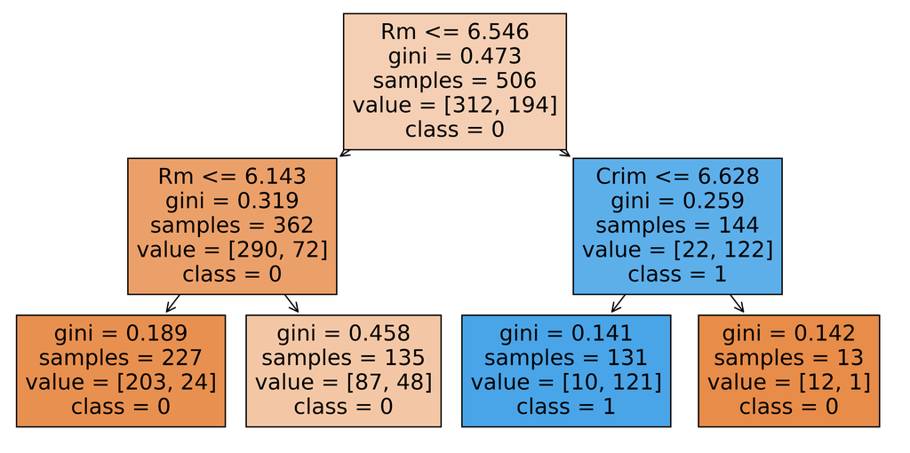

```python
fig, axes = plt.subplots(nrows = 1,ncols = 1,figsize = (12,6), dpi=400)
tree.plot_tree(decision_tree_classifier_with_depth,feature_names = independent_variables.columns, class_names=['0','1'],filled = True)
plt.show()
```

#### Samples is the number of instances in the entire tree at the root node it is 506 which is correct when you parse out data and you can see count above for independent/predicted variables in data set.

#### Class is 0 meand the dominant classification on that node which also mean is has more class = 0 than class = 1 at this point. In the root node RM is less than or equal to 6.546 this represents the first condition before the root node splits to create branches.

#### Value is total instance to test for information gain are seperated. I like to think its the split of total samples at each node.

#### Question 8 [3 pts]: Please download housing.header.binary.txt dataset from Canvas, and use Python (or R) to implement following tasks.

#### • Please use 80% of instances in the “housing.header.binary.txt” dataset to build a decision

#### tree classifier (using all features) to predict house value Medv [0.5 pt].

```python
import numpy as np
import matplotlib.pyplot as plt
import pandas as pd
from sklearn import tree
from sklearn.metrics import confusion_matrix
from sklearn import metrics
from sklearn.metrics import roc_auc_score
from sklearn.metrics import accuracy_score
from sklearn.model_selection import train_test_split
```

```python
q8dataframe = pd.read_csv("housing.header.binary.txt")
q8dataframe.head()
```

|  | Crim | Zn | Indus | Chas | Nox | Rm | Age | Dis | Rad | Tax | Ptratio | B | Lstat | Medv |
| --- | --- | --- | --- | --- | --- | --- | --- | --- | --- | --- | --- | --- | --- | --- |
| 0 | 0.00632 | 18.0 | 2.31 | 0 | 0.538 | 6.575 | 65.2 | 4.0900 | 1 | 296 | 15.3 | 396.90 | 4.98 | 1 |
| 1 | 0.02731 | 0.0 | 7.07 | 0 | 0.469 | 6.421 | 78.9 | 4.9671 | 2 | 242 | 17.8 | 396.90 | 9.14 | 0 |
| 2 | 0.02729 | 0.0 | 7.07 | 0 | 0.469 | 7.185 | 61.1 | 4.9671 | 2 | 242 | 17.8 | 392.83 | 4.03 | 1 |
| 3 | 0.03237 | 0.0 | 2.18 | 0 | 0.458 | 6.998 | 45.8 | 6.0622 | 3 | 222 | 18.7 | 394.63 | 2.94 | 1 |
| 4 | 0.06905 | 0.0 | 2.18 | 0 | 0.458 | 7.147 | 54.2 | 6.0622 | 3 | 222 | 18.7 | 396.90 | 5.33 | 1 |

```python
feature = q8dataframe.iloc[:,0:-1]
lab = q8dataframe.loc[:,['Medv']]
feature
```

|  | Crim | Zn | Indus | Chas | Nox | Rm | Age | Dis | Rad | Tax | Ptratio | B | Lstat |
| --- | --- | --- | --- | --- | --- | --- | --- | --- | --- | --- | --- | --- | --- |
| 0 | 0.00632 | 18.0 | 2.31 | 0 | 0.538 | 6.575 | 65.2 | 4.0900 | 1 | 296 | 15.3 | 396.90 | 4.98 |
| 1 | 0.02731 | 0.0 | 7.07 | 0 | 0.469 | 6.421 | 78.9 | 4.9671 | 2 | 242 | 17.8 | 396.90 | 9.14 |
| 2 | 0.02729 | 0.0 | 7.07 | 0 | 0.469 | 7.185 | 61.1 | 4.9671 | 2 | 242 | 17.8 | 392.83 | 4.03 |
| 3 | 0.03237 | 0.0 | 2.18 | 0 | 0.458 | 6.998 | 45.8 | 6.0622 | 3 | 222 | 18.7 | 394.63 | 2.94 |
| 4 | 0.06905 | 0.0 | 2.18 | 0 | 0.458 | 7.147 | 54.2 | 6.0622 | 3 | 222 | 18.7 | 396.90 | 5.33 |
| ... | ... | ... | ... | ... | ... | ... | ... | ... | ... | ... | ... | ... | ... |
| 501 | 0.06263 | 0.0 | 11.93 | 0 | 0.573 | 6.593 | 69.1 | 2.4786 | 1 | 273 | 21.0 | 391.99 | 9.67 |
| 502 | 0.04527 | 0.0 | 11.93 | 0 | 0.573 | 6.120 | 76.7 | 2.2875 | 1 | 273 | 21.0 | 396.90 | 9.08 |
| 503 | 0.06076 | 0.0 | 11.93 | 0 | 0.573 | 6.976 | 91.0 | 2.1675 | 1 | 273 | 21.0 | 396.90 | 5.64 |
| 504 | 0.10959 | 0.0 | 11.93 | 0 | 0.573 | 6.794 | 89.3 | 2.3889 | 1 | 273 | 21.0 | 393.45 | 6.48 |
| 505 | 0.04741 | 0.0 | 11.93 | 0 | 0.573 | 6.030 | 80.8 | 2.5050 | 1 | 273 | 21.0 | 396.90 | 7.88 |

506 rows × 13 columns

```python
lab
```

|  | Medv |
| --- | --- |
| 0 | 1 |
| 1 | 0 |
| 2 | 1 |
| 3 | 1 |
| 4 | 1 |
| ... | ... |
| 501 | 0 |
| 502 | 0 |
| 503 | 1 |
| 504 | 0 |
| 505 | 0 |

506 rows × 1 columns

```python
from sklearn.model_selection import train_test_split
trainA, testA, trainB, testB = train_test_split(feature,lab,test_size=.2,random_state=0)
print(trainA.shape,testA.shape,trainB.shape,testB.shape)
```

```
(404, 13) (102, 13) (404, 1) (102, 1)
```

```python
q8_decision_tree_object = tree.DecisionTreeClassifier()
q8_decision_tree_object.fit(trainA, trainB)
ppredictionforb= q8_decision_tree_object.predict(testA)
print(testB,ppredictionforb)
```

```
     Medv
329     0
371     1
219     1
403     0
78      0
..    ...
56      1
455     0
60      0
213     1
108     0

[102 rows x 1 columns] [1 0 0 0 0 0 1 0 0 0 0 0 0 0 1 1 0 1 1 0 1 0 0 1 0 0 0 0 1 0 0 0 0 0 1 0 0
 0 0 0 1 0 0 0 0 0 0 0 0 1 0 0 0 1 0 0 0 0 0 0 0 0 1 1 0 1 0 1 0 0 0 1 0 1
 1 0 1 0 0 0 1 0 0 1 1 1 1 0 1 0 0 0 0 1 0 1 0 1 0 0 1 0]
```

[output not shown]

[figure not shown]

```python
plt.rcParams.update({'font.size':17})
fig, axes = plt.subplots(nrows = 1,ncols = 1,figsize = (5,2), dpi=500)
tree.plot_tree(q8_decision_tree_object,feature_names=feature.columns, class_names =['0','1 '],filled = True)
```

## Report the performance of the classifier on the remaining 20% of instances in the

## “housing.header.binary.txt”

## o Report confusion table, TPR, FPR, and the Accuracy [0.5 pt]

## o Report the ROC curve [0.5 pt]

## o Report the AUC value [0.5 pt]

```python
q8_confusion_matrix = confusion_matrix(testB, ppredictionforb)
q8_confusion_matrix
```

```
array([[59,  5],
       [12, 26]], dtype=int64)
```

```python
def confusionmatrix(q8_confusion_matrix):
    true_negative, false_postivie, false_negative, true_positive = q8_confusion_matrix.ravel()
    print("*********************************************************")
    print('true negative',true_negative)
    print('false positive =',false_postivie)
    print('False negatuve =',false_negative)
    print('True positive =',true_positive)
    print("*********************************************************")
    accuracy = float(true_negative+true_positive)/float(true_negative+false_postivie+false_negative+true_positive)
    true_postive_rate = true_positive/(true_positive + false_negative)
    false_postive_rate = false_postivie/(false_postivie + true_negative)
    print("Accuracy Value= %f" % accuracy)
    print("Treu Postive Rate= %f" % true_postive_rate)
    print("False Positive Raye = %f" % false_postive_rate)
    print("*********************************************************")
```

```python
confusionmatrix(q8_confusion_matrix)
```

```
true negative 59
false positive = 5
False negatuve = 12
True positive = 26
Accuracy Value= 0.833333
Treu Postive Rate= 0.684211
False Positive Raye = 0.078125
```

```python
acc_score = accuracy_score(testB, ppredictionforb)
print("acc_score = " + str(acc_score))
```

```
acc_score = 0.8333333333333334
```

```python
probability_value_calced = q8_decision_tree_object.predict_proba(testA)
print(probability_value_calced[:10])
```

```
[[0. 1.]
 [1. 0.]
 [1. 0.]
 [1. 0.]
 [1. 0.]
 [1. 0.]
 [0. 1.]
 [1. 0.]
 [1. 0.]
 [1. 0.]]
```

```python
score_for_the_auc= roc_auc_score(testB,probability_value_calced[:,1])
print("AUC calculated value=" + str(score_for_the_auc))
```

```
AUC calculated value=0.8030427631578947
```

```python
fpr, tpr, thresholds = metrics.roc_curve(testB, probability_value_calced[:,1], pos_label=1)
print(fpr,tpr,thresholds)
```

```
[0.       0.078125 1.      ] [0.         0.68421053 1.        ] [2. 1. 0.]
```

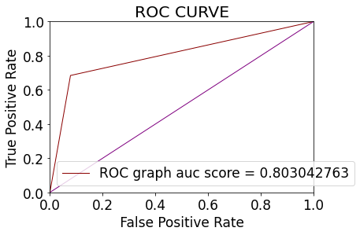

```python
def AucGraphCreator():
    plt.figure()
    lineWidth = 1
    plt.plot(fpr, tpr, color='darkRed',lw=lineWidth,
             label='ROC graph auc score = %0.9f'
             %score_for_the_auc)
    plt.xlabel('False Positive Rate')
    plt.xlabel(' False Positive Rate ')
    plt.ylabel(' True Positive Rate ')
    plt.title("ROC CURVE")
    plt.plot([0, 1], [0, 1],
             color='purple',
             lw=lineWidth,
             linestyle='-')
    plt.xlim([0.0, 1.0])
    plt.ylim([0.0, 1.0])
    plt.legend(loc='best')
    plt.show()
AucGraphCreator()
```

```python
df_created = pd.DataFrame([[0.03,13,3.5,0.3,0.58,4.1,68,4.98,3,225,17,396,7.56]],columns=['Crim','Zn','Indus','Chas','Nox','Rm','Age','Dis','Rad','Tax','Ptratio','B','Lstat'])
df_created
```

|  | Crim | Zn | Indus | Chas | Nox | Rm | Age | Dis | Rad | Tax | Ptratio | B | Lstat |
| --- | --- | --- | --- | --- | --- | --- | --- | --- | --- | --- | --- | --- | --- |
| 0 | 0.03 | 13 | 3.5 | 0.3 | 0.58 | 4.1 | 68 | 4.98 | 3 | 225 | 17 | 396 | 7.56 |

```python
new_predicted_Medv_value = q8_decision_tree_object.predict(df_created)
print(new_predicted_Medv_value)
```

```
[0]
```